# FINAL EXAM MACHINE LEARNING I

date: “30 April 2025”

author: Fernando San Segundo Barahona & Néstor Rodríguez Pérez

format: html: self-contained: true

**Important**

ChatGPT and other AI assistants are not allowed, but you can access Internet and your course files; do not hesitate using them, as it will probably be the best way to write the necessary code, check the documentation or solve coding issues.

**Warning**

**Please refrain from spending time in unrequested code or graphs.**

They will not count towards your grade and will only leave you with less time for the relevant parts of the exam.

# **Milk production dataset** (4 points)

The data is provided in the file

`milk_production.csv`

The meaning of the variables is as follows:

- The `DATE` of the observation.
- `MILK` production in thousands of tons.

Your goal is to compare different forecasting algorithms to predict the output variable `MILK`.

For your convenience, we import in the next cell some of the libraries for unsupervised learning we have seen in the course

```python
### Load necessary modules -------------------------------


import warnings
warnings.filterwarnings("ignore", category=FutureWarning)


import pandas as pd
import numpy as np
import scipy.stats as stats
import matplotlib.pyplot as plt
import seaborn as sns
sns.set_context('notebook')


# Ensure that matplotlib plots are displayed below each code cell
%matplotlib inline

# Machine Learning general libraries

from sklearn.metrics import mean_squared_error, mean_absolute_error

# statsmodels
import statsmodels.stats.api as sms
import statsmodels.api as sm
from statsmodels.formula.api import ols


# Time Series related imports

import datetime
from sklearn.model_selection import TimeSeriesSplit
import statsmodels.api as sm
# pmdarima
import pmdarima as pmd
# sktime
from sktime.utils.plotting import plot_series
from sktime.forecasting.base import ForecastingHorizon
from sktime.forecasting.model_selection import temporal_train_test_split
from sktime.split import ExpandingWindowSplitter
from sktime.transformations.series.boxcox import BoxCoxTransformer
from sktime.forecasting.naive import NaiveForecaster
from sktime.performance_metrics.forecasting import mean_absolute_error, mean_absolute_percentage_error
from sktime.forecasting.model_evaluation import evaluate
from sktime.forecasting.compose import TransformedTargetForecaster


import statsmodels.tsa as tsa
# from statsmodels.tsa.seasonal import seasonal_decompose, STL
# from statsmodels.tsa.stattools import adfuller, kpss
# from statsmodels.tsa.stattools import adfuller, kpss
# from statsmodels.tsa.arima_process import ArmaProcess
# from statsmodels.tsa.stattools import acf, pacf
from statsmodels.tsa.arima.model import ARIMA as smARIMA
# from sktime.forecasting.sarimax import SARIMAX


from fc_4_5_utils.utils import *
```

**Question 0: Exploratory Data Analysis (EDA) and data preparation (1 point).**

```python
df = pd.read_csv('./milk_production.csv', sep=';')
df.head(13)
```

|  | DATE | MILK |
| --- | --- | --- |
| 0 | 1962-01-31 | 589.0 |
| 1 | 1962-02-28 | 561.0 |
| 2 | 1962-03-31 | 640.0 |
| 3 | 1962-04-30 | 656.0 |
| 4 | 1962-05-31 | 727.0 |
| 5 | 1962-06-30 | 697.0 |
| 6 | 1962-07-31 | 640.0 |
| 7 | 1962-08-31 | 599.0 |
| 8 | 1962-08-31 | 599.0 |
| 9 | 1962-09-30 | 568.0 |
| 10 | 1962-10-31 | 577.0 |
| 11 | 1962-12-31 | 582.0 |
| 12 | 1963-01-31 | 600.0 |

```python
df.tail(13)
```

|  | DATE | MILK |
| --- | --- | --- |
| 155 | 1974-12-31 | 813.0 |
| 156 | 1975-01-31 | 834.0 |
| 157 | 1975-02-28 | 782.0 |
| 158 | 1975-03-31 | 892.0 |
| 159 | 1975-04-30 | 903.0 |
| 160 | 1975-05-31 | 966.0 |
| 161 | 1975-06-30 | 937.0 |
| 162 | 1975-07-31 | 896.0 |
| 163 | 1975-08-31 | 858.0 |
| 164 | 1975-09-30 | 817.0 |
| 165 | 1975-10-31 | 827.0 |
| 166 | 1975-11-30 | 797.0 |
| 167 | 1975-12-31 | 843.0 |

Note that this is **monthly data**.

Begin by using info

```python
df.info()
```

```
<class 'pandas.core.frame.DataFrame'>
RangeIndex: 168 entries, 0 to 167
Data columns (total 2 columns):
 #   Column  Non-Null Count  Dtype
---  ------  --------------  -----
 0   DATE    168 non-null    object
 1   MILK    167 non-null    float64
dtypes: float64(1), object(1)
memory usage: 2.8+ KB
```

```python
target = ["MILK"]
```

We have explicit missing data

```python
df.isna().sum()
```

```
DATE    0
MILK    1
dtype: int64
```

We also have time gaps

```python
df['DATE'] = pd.to_datetime(df['DATE'], format='%Y-%m-%d')
# Find start and end date of the rime series
start_date = df["DATE"].min()
end_date = df["DATE"].max()
print(start_date, end_date)
```

```
1962-01-31 00:00:00 1975-12-31 00:00:00
```

```python
# Generate a full range of months
full_range = pd.date_range(start=start_date, end=end_date, freq='ME')  # 'MS' ensures month start
full_range
```

```
DatetimeIndex(['1962-01-31', '1962-02-28', '1962-03-31', '1962-04-30',
               '1962-05-31', '1962-06-30', '1962-07-31', '1962-08-31',
               '1962-09-30', '1962-10-31',
               ...
               '1975-03-31', '1975-04-30', '1975-05-31', '1975-06-30',
               '1975-07-31', '1975-08-31', '1975-09-30', '1975-10-31',
               '1975-11-30', '1975-12-31'],
              dtype='datetime64[ns]', length=168, freq='ME')
```

```python
missing_dates = full_range.difference(df["DATE"])
missing_dates
```

```
DatetimeIndex(['1962-11-30'], dtype='datetime64[ns]', freq='ME')
```

And dupliicated data:

```python
df[df.duplicated(keep=False)]
```

|  | DATE | MILK |
| --- | --- | --- |
| 7 | 1962-08-31 | 599.0 |
| 8 | 1962-08-31 | 599.0 |

We begin cleaning by removing the duplicated data

```python
df = df.drop_duplicates(keep='first')
df.index[df.index.duplicated()]
```

```
Index([], dtype='int64')
```

Now we are ready to set the temporal index:

```python
df.set_index("DATE", inplace=True)
```

We add the index values for the time gaps.

```python
df = df.reindex(full_range)
```

And we check that no time gaps are left:

```python
full_range.difference(df.index)
```

```
DatetimeIndex([], dtype='datetime64[ns]', freq='ME')
```

```python
df.index.name = 'DATE'
df.head()
```

| DATE | MILK |
| --- | --- |
| 1962-01-31 | 589.0 |
| 1962-02-28 | 561.0 |
| 1962-03-31 | 640.0 |
| 1962-04-30 | 656.0 |
| 1962-05-31 | 727.0 |

As a result we now have more missing data.

```python
df.info()
```

```
<class 'pandas.core.frame.DataFrame'>
DatetimeIndex: 168 entries, 1962-01-31 to 1975-12-31
Freq: ME
Data columns (total 1 columns):
 #   Column  Non-Null Count  Dtype
---  ------  --------------  -----
 0   MILK    166 non-null    float64
dtypes: float64(1)
memory usage: 6.7 KB
```

We will fill them using linear interpolation:

```python
df[target] = df[target].interpolate(method="linear")
```

Now we have no missing data, and no time gaps or duplicated data, so we can proceed with the rest of the analysis.

```python
df.info()
```

```
<class 'pandas.core.frame.DataFrame'>
DatetimeIndex: 168 entries, 1962-01-31 to 1975-12-31
Freq: ME
Data columns (total 1 columns):
 #   Column  Non-Null Count  Dtype
---  ------  --------------  -----
 0   MILK    168 non-null    float64
dtypes: float64(1)
memory usage: 6.7 KB
```

### Exploratory plots

We begin by plotting the whole time series. Seasonality and trend are clearly visible.

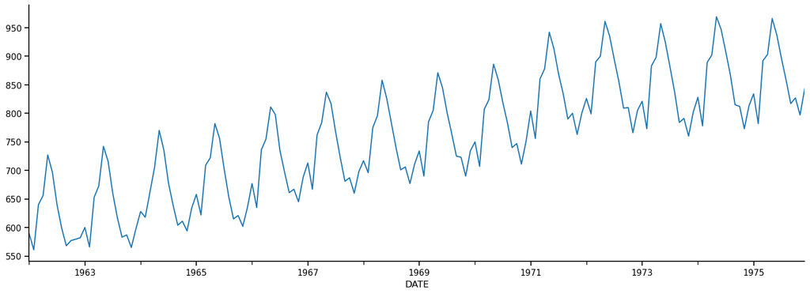

```python
fig, ax = plt.subplots(figsize=(18, 6))
df[target].plot(ax=ax, legend=False)
plt.show();plt.close()
```

Since this is monthly data the expected seasonality is (yearly) sp = 12.

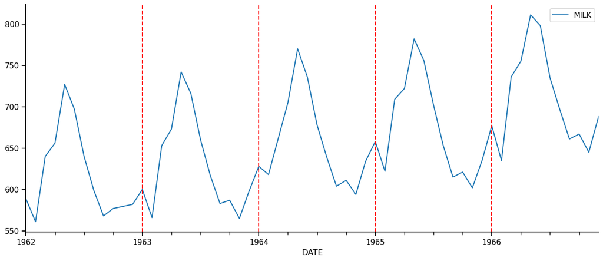

```python
sp = 12
plt.figure(figsize=(15, 6))
df[target].head(sp * 5).plot(ax=plt.gca())
for a in range(sp, 5*sp, sp):
    plt.axvline(x=df.index[a], color='red', linestyle='--')
plt.show();plt.close()
```

### Temporal split into training and testing sets

```python
y = df[target]
```

To use the last rows as test set we do:

```python
test_size=10
y_train, y_test = temporal_train_test_split(y, test_size=test_size)
y_train.shape, y_test.shape
```

```
((158, 1), (10, 1))
```

And we check the split as follows:

```python
y_train
```

| DATE | MILK |
| --- | --- |
| 1962-01-31 | 589.0 |
| 1962-02-28 | 561.0 |
| 1962-03-31 | 640.0 |
| 1962-04-30 | 656.0 |
| 1962-05-31 | 727.0 |
| ... | ... |
| 1974-10-31 | 812.0 |
| 1974-11-30 | 773.0 |
| 1974-12-31 | 813.0 |
| 1975-01-31 | 834.0 |
| 1975-02-28 | 782.0 |

158 rows × 1 columns

```python
y_train.index.freq
```

```
<MonthEnd>
```

```python
y_test
```

| DATE | MILK |
| --- | --- |
| 1975-03-31 | 892.0 |
| 1975-04-30 | 903.0 |
| 1975-05-31 | 966.0 |
| 1975-06-30 | 937.0 |
| 1975-07-31 | 896.0 |
| 1975-08-31 | 858.0 |
| 1975-09-30 | 817.0 |
| 1975-10-31 | 827.0 |
| 1975-11-30 | 797.0 |
| 1975-12-31 | 843.0 |

We will also prepare now the validation strategy for the models. Recall that we will use a rolling forecast origin with a forecasting horizon of 1 month and with the refit strategy. With sktime we can use the `ExpandingWindowSplit` class.

```python
initial_window = int(y_train.shape[0] * 0.75)
cv_splitter = ExpandingWindowSplitter(initial_window=initial_window, fh=[1], step_length=4)
folds = list(cv_splitter.split(y_train))
len(folds)
```

```
10
```

```python
y_train.index[folds[0][0]]
```

```
DatetimeIndex(['1962-01-31', '1962-02-28', '1962-03-31', '1962-04-30',
               '1962-05-31', '1962-06-30', '1962-07-31', '1962-08-31',
               '1962-09-30', '1962-10-31',
               ...
               '1971-01-31', '1971-02-28', '1971-03-31', '1971-04-30',
               '1971-05-31', '1971-06-30', '1971-07-31', '1971-08-31',
               '1971-09-30', '1971-10-31'],
              dtype='datetime64[ns]', name='DATE', length=118, freq=None)
```

**Question 1 : Identification and Fitting Process of a *seasonal last* naive model as baseline (0.5 points)**

- Fit **a seasonal last naive** model to the data.
- Evaluate the performance of the model using MAPE. Thie will be the performance measure used for the selection between the models.
- Visualize the results of the baseline models.

```python
modelDict = {}
```

### Seasonal last

```python
seasonal_last = NaiveForecaster(strategy="last", sp=sp)
```

```python
model_name = "seasonal_last"
model = seasonal_last
```

```python
train_cv_results = evaluate(
    forecaster=model,
    y=y_train,
    cv=cv_splitter,
    strategy="refit",  # refit model on each fold
    scoring=mean_absolute_percentage_error,
    return_data=True
)
```

```python
val_avrg_mape = train_cv_results.iloc[:, 0].mean()
val_avrg_mape
```

```
0.021762120028955424
```

```python
test_fh = 1
step_length = 1

# Create a splitter that walks through the test set
cv_test = ExpandingWindowSplitter(
    initial_window=y_train.shape[0],
    step_length=step_length,
    fh=test_fh
)
```

```python
%%time

test_cv_results = evaluate(
    forecaster=model,
    y=df[target],
    cv=cv_test,
    strategy="refit",
    scoring=mean_absolute_percentage_error,
    return_data=True
)
```

```
CPU times: user 169 ms, sys: 7.01 ms, total: 176 ms
Wall time: 171 ms
```

```python
test_avrg_mape = test_cv_results.iloc[:, 0].mean()
test_avrg_mape
```

```
0.012841690483067287
```

```python
model_test_pred = np.array([row.iloc[0] for row in test_cv_results["y_pred"]])
model_test_pred = pd.DataFrame(model_test_pred, index=y_test.index, columns=[model_name + "_pred"])
```

```python
model_test_mape = mean_absolute_percentage_error(y_test[target], model_test_pred)
model_test_mape
```

```
0.012841690483067287
```

```python
modelDict[model_name] = {
    'model': model,
    'val_avrg_mape': val_avrg_mape,
    'train_cv_results': train_cv_results,
    'test_avrg_mape': test_avrg_mape,
    'test_mape': model_test_mape,
    'test_cv_results': test_cv_results,
    'model_test_pred': model_test_pred
}
```

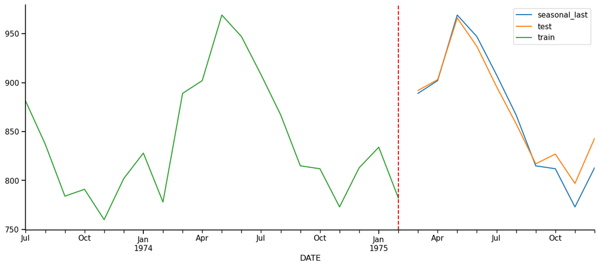

```python
plt.figure(figsize=(15, 6))
for model_name in modelDict.keys():
    modelDict[model_name]['model_test_pred'].plot(ax=plt.gca())
y_test.plot(ax=plt.gca())
y_train.tail(20).plot(ax = plt.gca())
# y.iloc[(y_train.shape[0]- 50):(y_train.shape[0] + 1)].plot(ax=plt.gca())
plt.legend(list(modelDict.keys()) + ['test', 'train'])
plt.axvline(x = y_train.index[-1], color='red', linestyle='--')
plt.show();plt.close()
```

**Question 2: SARIMA model (1.5 points)**

- Select and diagnose a SARIMA model for the time series.
- Evaluate the performance of this model in validation and test.
- Visualize the predictions of this model.

```python
y_train_cp = y_train.copy()
```

```python
box_cox = False

Y = target[0]
Y_original = Y

if box_cox:
    # y_train_original = y_train.copy()
    bxcx_transformer = BoxCoxTransformer()
    transformed_y_train = bxcx_transformer.fit_transform(y_train[[Y]])
    y_train_cp[Y + "_bxcx"] = transformed_y_train
    # y_train.insert(-1, Y + "_bxcx", transformed_y_train)


    Y = Y + "_bxcx"
    print(f"lambda = {bxcx_transformer.lambda_:.3f}")
```

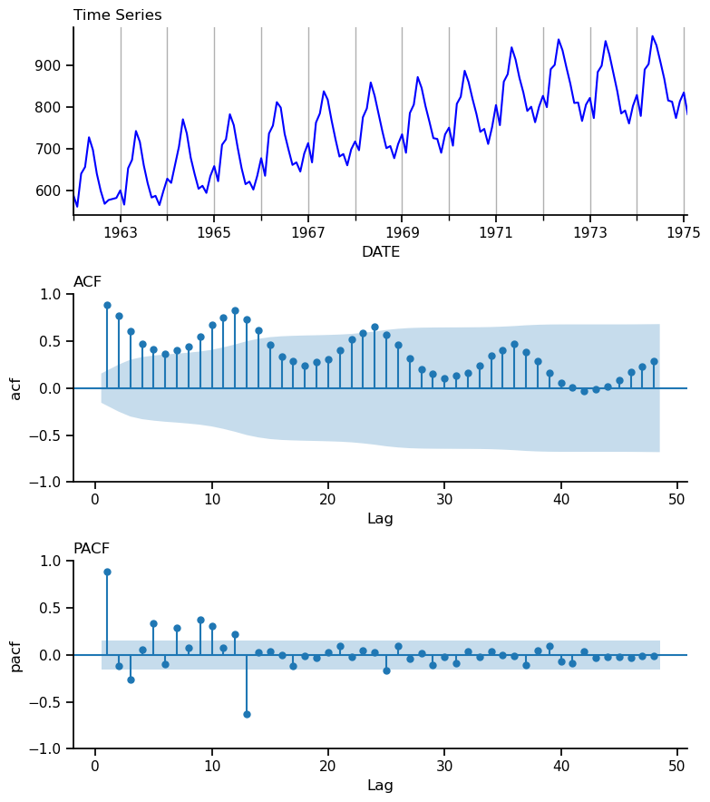

```python
plot_acf_pacf(df_ts=y_train_cp, var=Y, lags= 4 * sp)
```

```python
ndiffs, nsdiffs = pmd.arima.ndiffs, pmd.arima.nsdiffs

y_train_cp[Y + "_diff"] = y_train_cp[Y]
y_train_cp
```

| DATE | MILK | MILK_diff |
| --- | --- | --- |
| 1962-01-31 | 589.0 | 589.0 |
| 1962-02-28 | 561.0 | 561.0 |
| 1962-03-31 | 640.0 | 640.0 |
| 1962-04-30 | 656.0 | 656.0 |
| 1962-05-31 | 727.0 | 727.0 |
| ... | ... | ... |
| 1974-10-31 | 812.0 | 812.0 |
| 1974-11-30 | 773.0 | 773.0 |
| 1974-12-31 | 813.0 | 813.0 |
| 1975-01-31 | 834.0 | 834.0 |
| 1975-02-28 | 782.0 | 782.0 |

158 rows × 2 columns

```python
D = nsdiffs(y_train_cp[Y], m=sp)
print(f"Number of suggested seasonal (sp = {sp}) differences = {D}")
```

```
Number of suggested seasonal (sp = 12) differences = 1
```

```python
D = 1
if (D > 0):
    y_train_cp[Y + "_diff"] = y_train_cp[Y].diff(periods=D * sp)

print(f"Number of applied seasonal differences = {D}")
```

```
Number of applied seasonal differences = 1
```

```python
y_train_cp
```

| DATE | MILK | MILK_diff |
| --- | --- | --- |
| 1962-01-31 | 589.0 | NaN |
| 1962-02-28 | 561.0 | NaN |
| 1962-03-31 | 640.0 | NaN |
| 1962-04-30 | 656.0 | NaN |
| 1962-05-31 | 727.0 | NaN |
| ... | ... | ... |
| 1974-10-31 | 812.0 | 21.0 |
| 1974-11-30 | 773.0 | 13.0 |
| 1974-12-31 | 813.0 | 11.0 |
| 1975-01-31 | 834.0 | 6.0 |
| 1975-02-28 | 782.0 | 4.0 |

158 rows × 2 columns

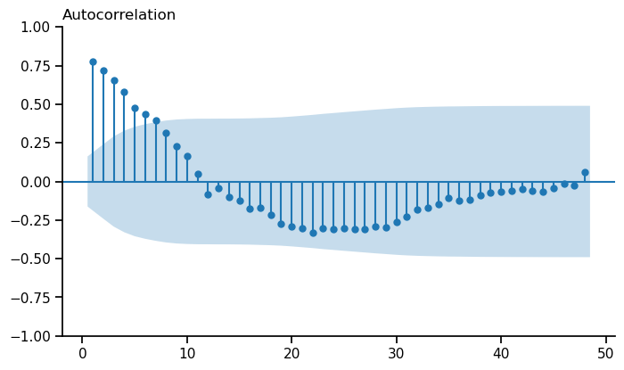

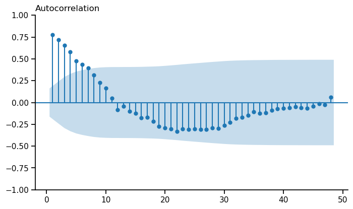

```python
sm.graphics.tsa.plot_acf(y_train_cp[Y + "_diff"].dropna(), lags=4 * sp, zero=False)
```

```python
d =  ndiffs(y_train_cp[Y].dropna())
print("Suggestions for regular differences: ", d)
```

```
Suggestions for regular differences:  1
```

```python
d = 1
if (d > 0):
    y_train_cp[Y + "_diff"] = y_train_cp[Y + "_diff"].diff(d)
    # y_train_cp[Y + "_diff"] = y_train_cp[Y + "_diff"].dropna().diff(d)
    Ydiff = Y + "_diff"

print(f"Number of applied regular differences = {d}")
```

```
Number of applied regular differences = 1
```

```python
y_train_cp
```

| DATE | MILK | MILK_diff |
| --- | --- | --- |
| 1962-01-31 | 589.0 | NaN |
| 1962-02-28 | 561.0 | NaN |
| 1962-03-31 | 640.0 | NaN |
| 1962-04-30 | 656.0 | NaN |
| 1962-05-31 | 727.0 | NaN |
| ... | ... | ... |
| 1974-10-31 | 812.0 | -10.0 |
| 1974-11-30 | 773.0 | -8.0 |
| 1974-12-31 | 813.0 | -2.0 |
| 1975-01-31 | 834.0 | -5.0 |
| 1975-02-28 | 782.0 | -2.0 |

158 rows × 2 columns

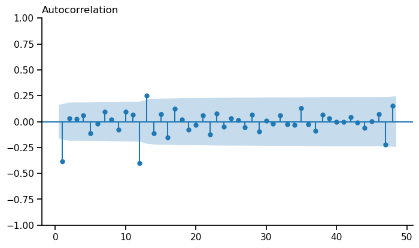

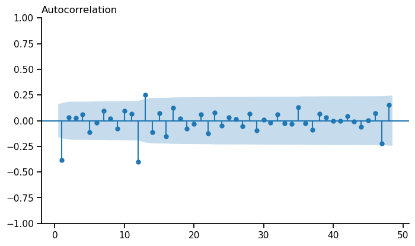

```python
sm.graphics.tsa.plot_acf(y_train_cp[Y + "_diff"].dropna(), lags=4 * sp, zero=False)
```

```python
Y + "_diff", Ydiff
```

```
('MILK_diff', 'MILK_diff')
```

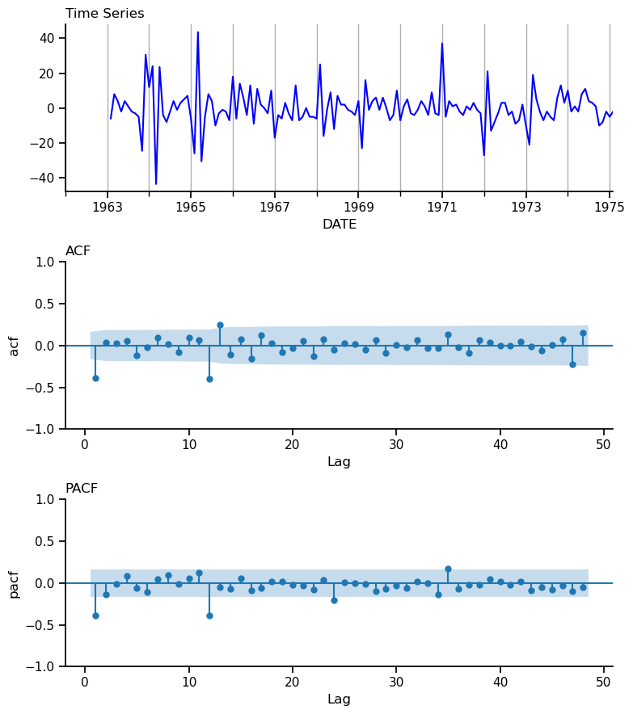

```python
plot_acf_pacf(df_ts=y_train_cp, var=Ydiff, lags= 4 * sp)
plt.show();plt.close()
```

```python
D, d
```

```
(1, 1)
```

```python
p = 1
q = 0
P = 0
Q = 1
```

```python
box_cox
```

```
False
```

```python
from sktime.forecasting.compose import TransformedTargetForecaster
from sktime.forecasting.arima import ARIMA as skARIMA

if not box_cox:
    print
    bxcx_trnsf = BoxCoxTransformer(method = "fixed", lambda_fixed=1)
else:
    print("Using Box-Cox transformation")
    bxcx_trnsf = BoxCoxTransformer()


skARIMA_forecaster = TransformedTargetForecaster(steps=[
    ("boxcox", bxcx_trnsf),
    ("model", skARIMA(order=(p,d,q),
                      seasonal_order=(P,D,Q,sp),
                      with_intercept=False))
])

model_name = "Arima"
model = skARIMA_forecaster
```

```python
skARIMA_forecaster.fit(y_train[Y_original])
```

```
TransformedTargetForecaster(steps=[('boxcox',
                                    BoxCoxTransformer(lambda_fixed=1,
                                                      method='fixed')),
                                   ('model',
                                    ARIMA(order=(1, 1, 0),
                                          seasonal_order=(0, 1, 1, 12),
                                          with_intercept=False))])
```

```python
skARIMA_forecaster.forecaster_.summary()
```

SARIMAX Results

| Dep. Variable: | y | No. Observations: | 158 |
| --- | --- | --- | --- |
| Model: | SARIMAX(1, 1, 0)x(0, 1, [1], 12) | Log Likelihood | -523.376 |
| Date: | Mon, 11 May 2026 | AIC | 1052.752 |
| Time: | 11:27:23 | BIC | 1061.682 |
| Sample: | 01-31-1962 | HQIC | 1056.381 |
|  | - 02-28-1975 |  |  |
| Covariance Type: | opg |  |  |

|  | coef | std err | z | P>\|z\| | [0.025 | 0.975] |
| --- | --- | --- | --- | --- | --- | --- |
| ar.L1 | -0.3649 | 0.061 | -6.014 | 0.000 | -0.484 | -0.246 |
| ma.S.L12 | -0.5945 | 0.087 | -6.844 | 0.000 | -0.765 | -0.424 |
| sigma2 | 77.0211 | 7.656 | 10.061 | 0.000 | 62.016 | 92.026 |

| Ljung-Box (L1) (Q): | 0.36 | Jarque-Bera (JB): | 21.09 |
| --- | --- | --- | --- |
| Prob(Q): | 0.55 | Prob(JB): | 0.00 |
| Heteroskedasticity (H): | 0.41 | Skew: | 0.34 |
| Prob(H) (two-sided): | 0.00 | Kurtosis: | 4.74 |

Warnings:  
[1] Covariance matrix calculated using the outer product of gradients (complex-step).

```python
residuals = skARIMA_forecaster.predict_residuals(y_train[Y_original]).dropna()
resid_df = pd.DataFrame({'residuals':residuals})
```

Diagnostic plots for the residuals.

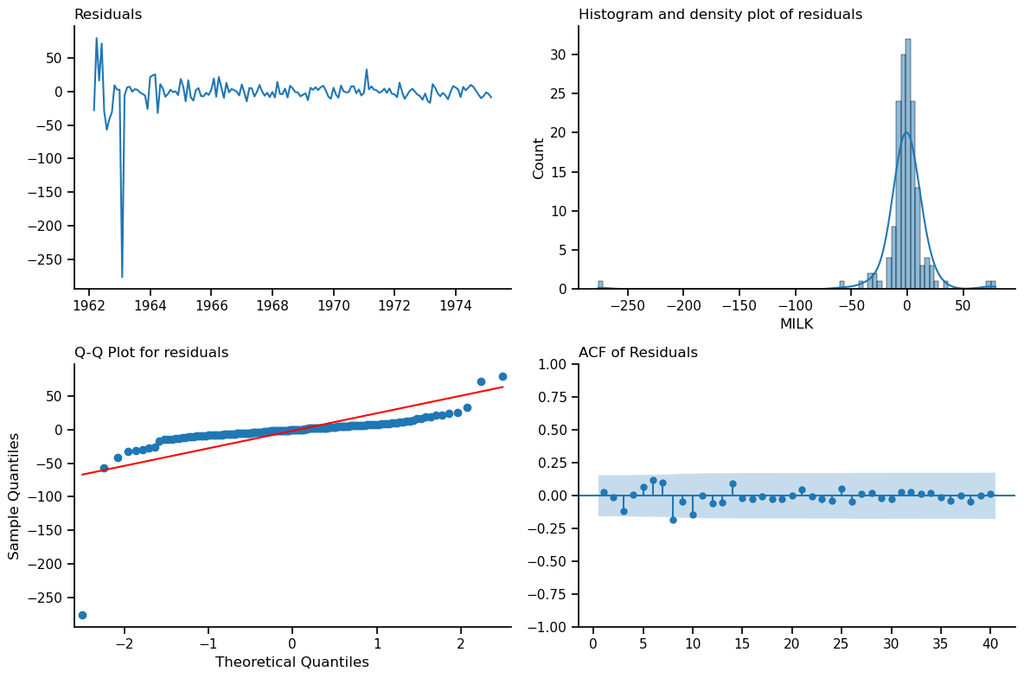

```python
plt.figure(figsize=(12, 8))

plt.subplot(221)
plt.plot(residuals)
plt.title("Residuals")

plt.subplot(222)
sns.histplot(residuals, kde=True)
plt.title("Histogram and density plot of residuals")

plt.subplot(223)
sm.qqplot(residuals, line='s', ax=plt.gca())
plt.title("Q-Q Plot for residuals")

plt.subplot(224)
sm.graphics.tsa.plot_acf(residuals, lags=40, ax=plt.gca(), zero=False)
plt.title("ACF of Residuals")

plt.tight_layout()
plt.show()
```

```python
sm.stats.acorr_ljungbox(residuals, lags= 1.5 * sp, return_df=True)
```

|  | lb_stat | lb_pvalue |
| --- | --- | --- |
| 1 | 0.129431 | 0.719023 |
| 2 | 0.152632 | 0.926523 |
| 3 | 2.318030 | 0.509076 |
| 4 | 2.328888 | 0.675515 |
| 5 | 3.075111 | 0.688407 |
| 6 | 5.552898 | 0.475086 |
| 7 | 7.180129 | 0.410369 |
| 8 | 12.667729 | 0.123805 |
| 9 | 12.968378 | 0.164042 |
| 10 | 16.342933 | 0.090227 |
| 11 | 16.344466 | 0.128817 |
| 12 | 16.867762 | 0.154640 |
| 13 | 17.274683 | 0.187050 |
| 14 | 18.740391 | 0.175108 |
| 15 | 18.784796 | 0.223652 |
| 16 | 18.910883 | 0.273312 |
| 17 | 18.914414 | 0.333467 |
| 18 | 19.034764 | 0.389686 |

```python
train_cv_results = evaluate(
    forecaster=model,
    y=y_train,
    cv=cv_splitter,
    strategy="refit",  # refit model on each fold
    scoring=mean_absolute_percentage_error,
    return_data=True
)
```

```python
val_avrg_mape = train_cv_results.iloc[:, 0].mean()
val_avrg_mape
```

```
0.007436897355602124
```

```python
test_fh = 1
step_length = 1

# Create a splitter that walks through the test set
cv_test = ExpandingWindowSplitter(
    initial_window=y_train.shape[0],
    step_length=step_length,
    fh=test_fh
)
```

```python
%%time

test_cv_results = evaluate(
    forecaster=model,
    y=df[Y],
    cv=cv_test,
    strategy="refit",
    scoring=mean_absolute_percentage_error,
    return_data=True
)
```

```
CPU times: user 8.08 s, sys: 6.77 s, total: 14.8 s
Wall time: 1.34 s
```

```python
test_avrg_mape = test_cv_results.iloc[:, 0].mean()
test_avrg_mape
```

```
0.00585894328784085
```

```python
model_test_pred = np.array([row.iloc[0] for row in test_cv_results["y_pred"]])
model_test_pred = pd.DataFrame(model_test_pred, index=y_test.index, columns=[model_name + "_pred"])
```

```python
model_test_mape = mean_absolute_percentage_error(y_test[Y_original], model_test_pred)
model_test_mape
```

```
0.00585894328784085
```

```python
modelDict[model_name] = {
    'model': model,
    'val_avrg_mape': val_avrg_mape,
    'train_cv_results': train_cv_results,
    'test_avrg_mape': test_avrg_mape,
    'test_mape': model_test_mape,
    'test_cv_results': test_cv_results,
    'model_test_pred': model_test_pred
}
```

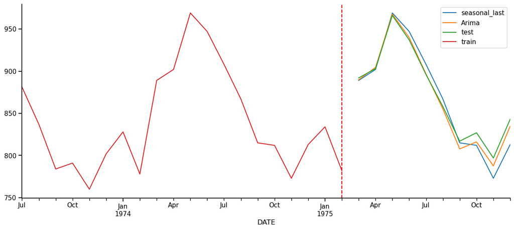

```python
plt.figure(figsize=(15, 6))
for model_name in modelDict.keys():
    modelDict[model_name]['model_test_pred'].plot(ax=plt.gca())
y_test.plot(ax=plt.gca())
y_train.tail(20).plot(ax = plt.gca())
# y.iloc[(y_train.shape[0]- 50):(y_train.shape[0] + 1)].plot(ax=plt.gca())
plt.legend(list(modelDict.keys()) + ['test', 'train'])
plt.axvline(x = y_train.index[-1], color='red', linestyle='--')
plt.show();plt.close()
```

**Question 3 : Gradient boosting model (0.5 points)**

- Fit a gradient boosting model. Use grid search to select the hyperparameters for this model.
- Evaluate the performance of this model in validation and test.
- Visualize the predictions of this model.

```python
from sklearn.ensemble import GradientBoostingRegressor
from sktime.forecasting.compose import make_reduction


base_regressor = GradientBoostingRegressor(random_state=2025)

boosting_forecaster = make_reduction(
    estimator=base_regressor,
    window_length= 3 * sp,
    strategy="recursive"
)

hyper_grid = {
    "estimator__n_estimators": [100, 200],
    "estimator__learning_rate": [0.05, 0.1, 0.2],
    "estimator__max_depth": [3, 5]
}
```

```python
cv_splitter
```

```
ExpandingWindowSplitter(fh=[1], initial_window=118, step_length=4)
```

```python
from sktime.forecasting.model_selection import ForecastingGridSearchCV

grid_search_cv_boosting = ForecastingGridSearchCV(
    forecaster=boosting_forecaster,
    param_grid=hyper_grid,
    cv=cv_splitter,
    scoring=mean_absolute_percentage_error,
    verbose=1
)
```

```python
grid_search_cv_boosting.fit(y_train)
```

```
Fitting 10 folds for each of 12 candidates, totalling 120 fits
```

```
ForecastingGridSearchCV(cv=ExpandingWindowSplitter(fh=[1], initial_window=118,
                                                   step_length=4),
                        forecaster=RecursiveTabularRegressionForecaster(estimator=GradientBoostingRegressor(random_state=2025),
                                                                        window_length=36),
                        param_grid={'estimator__learning_rate': [0.05, 0.1,
                                                                 0.2],
                                    'estimator__max_depth': [3, 5],
                                    'estimator__n_estimators': [100, 200]},
                        scoring=<function mean_absolute_percentage_error at 0x3427501f0>,
                        verbose=1)
```

```python
print("Best Parameters:", grid_search_cv_boosting.best_params_)
```

```
Best Parameters: {'estimator__learning_rate': 0.05, 'estimator__max_depth': 3, 'estimator__n_estimators': 200}
```

```python
final_boosting_model = grid_search_cv_boosting.best_forecaster_
final_boosting_model

model_name = "Boosting"
model = final_boosting_model
```

```python
train_cv_results = evaluate(
    forecaster=model,
    y=y_train,
    cv=cv_splitter,
    strategy="refit",  # refit model on each fold
    scoring=mean_absolute_percentage_error,
    return_data=True
)
```

```python
val_avrg_mape = train_cv_results.iloc[:, 0].mean()
val_avrg_mape
```

```
0.01867771791550558
```

```python
test_fh = 1
step_length = 1

# Create a splitter that walks through the test set
cv_test = ExpandingWindowSplitter(
    initial_window=y_train.shape[0],
    step_length=step_length,
    fh=test_fh
)
```

```python
%%time

test_cv_results = evaluate(
    forecaster=model,
    y=df[Y],
    cv=cv_test,
    strategy="refit",
    scoring=mean_absolute_percentage_error,
    return_data=True
)
```

```
CPU times: user 1.42 s, sys: 10.1 ms, total: 1.43 s
Wall time: 1.43 s
```

```python
test_avrg_mape = test_cv_results.iloc[:, 0].mean()
test_avrg_mape
```

```
0.017335767484992787
```

```python
model_test_pred = np.array([row.iloc[0] for row in test_cv_results["y_pred"]])
model_test_pred = pd.DataFrame(model_test_pred, index=y_test.index, columns=[model_name + "_pred"])
```

```python
model_test_mape = mean_absolute_percentage_error(y_test[Y_original], model_test_pred)
model_test_mape
```

```
0.017335767484992787
```

```python
modelDict[model_name] = {
    'model': model,
    'val_avrg_mape': val_avrg_mape,
    'train_cv_results': train_cv_results,
    'test_avrg_mape': test_avrg_mape,
    'test_mape': model_test_mape,
    'test_cv_results': test_cv_results,
    'model_test_pred': model_test_pred
}
```

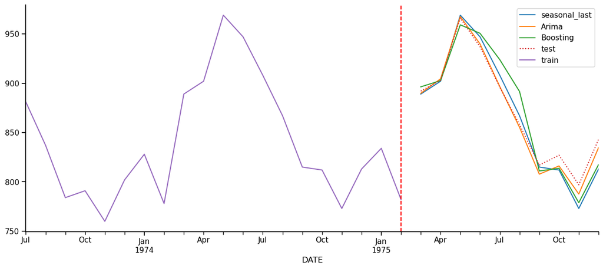

```python
plt.figure(figsize=(15, 6))
for model_name in modelDict.keys():
    modelDict[model_name]['model_test_pred'].plot(ax=plt.gca())
y_test.plot(ax=plt.gca(), linestyle=':')
y_train.tail(20).plot(ax = plt.gca())
# y.iloc[(y_train.shape[0]- 50):(y_train.shape[0] + 1)].plot(ax=plt.gca())
plt.legend(list(modelDict.keys()) + ['test', 'train'])
plt.axvline(x = y_train.index[-1], color='red', linestyle='--')
plt.show();plt.close()
```

**Question 4: Final model comparison and conclusions (0.5 points)**

- Summarize your findings from the comparative analysis of these forecasting models.

```python
model_mapes_df = pd.DataFrame({'model_name':modelDict.keys(),
                              'val_avrg_mape': [modelDict[model_name]['val_avrg_mape'] for model_name in modelDict.keys()],
                              'test_mape': [modelDict[model_name]['test_mape'] for model_name in modelDict.keys()],
                              'test_avrg_mape': [modelDict[model_name]['test_avrg_mape'] for model_name in modelDict.keys()]})

model_mapes_df
model_mapes_df.sort_values(by='val_avrg_mape', inplace=True)
model_mapes_df[['model_name', 'val_avrg_mape', 'test_mape']]
```

|  | model_name | val_avrg_mape | test_mape |
| --- | --- | --- | --- |
| 1 | Arima | 0.007437 | 0.005859 |
| 2 | Boosting | 0.018678 | 0.017336 |
| 0 | seasonal_last | 0.021762 | 0.012842 |